# `dplyr`: Data Pliers in R

I don’t know where the `y` comes from.

Author

Affiliation

Dr. Devan Becker

Wilfrid Laurier University

```r
# This should work if you've already ran `install.packages("tidyverse")` at some point.
library(tidyverse)
```

Bascially, `dplyr` is a set of functions that help manipulate data into a form that’s useful to us.

## 0.1 Why it’s called the `tidyverse`

A `data.frame` is basically a simple excel spreadsheet. A **tidy** data frame is defined as follows:

- Columns represent variables.
- Rows represent observations.

We’ll se throughout the course that this makes it very easy to manage - plots and summary statistics just work better with tidy data.

For example, the `mpg` data are tidy:

```r
head(mpg)
```

```
# A tibble: 6 × 11
  manufacturer model displ  year   cyl trans      drv     cty   hwy fl    class
  <chr>        <chr> <dbl> <int> <int> <chr>      <chr> <int> <int> <chr> <chr>
1 audi         a4      1.8  1999     4 auto(l5)   f        18    29 p     compa…
2 audi         a4      1.8  1999     4 manual(m5) f        21    29 p     compa…
3 audi         a4      2    2008     4 manual(m6) f        20    31 p     compa…
4 audi         a4      2    2008     4 auto(av)   f        21    30 p     compa…
5 audi         a4      2.8  1999     6 auto(l5)   f        16    26 p     compa…
6 audi         a4      2.8  1999     6 manual(m5) f        18    26 p     compa…
```

The first row represents a single car. The first column is the manufacturer for that car. Each row is an obs, each column a measurement on that obs.

Because of this, it’s easy to make plots like this one from last class:

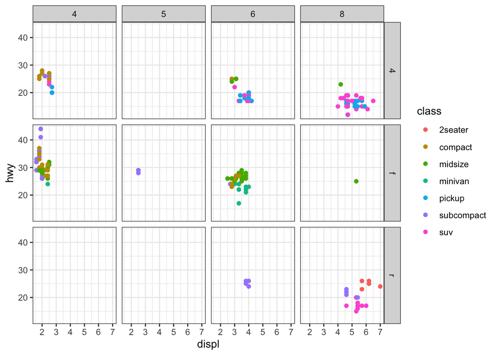

```r
ggplot(data = mpg) +
    geom_point(mapping = aes(x = displ, y = hwy, colour = class))+
    facet_grid(rows = vars(drv), cols = vars(cyl)) +
    theme_bw()
```

## 0.2 Preliminary: the Pipe

The “pipe” operator in R is `|>`. It takes whatever is on the left and puts it as the *first* argument of the function on the right.

- `x |> f()` is equivalent to `f(x)`.
- `x |> f(y)` is equivalent to `f(x, y)`
- `x |> f() |> g() |> h(y)` is equivalent to:
  - `f(x) |> g() |> h()`
  - `g(f(x)) |> h()`
  - `h(g(f(x)))`
  - In other words, the pipe works left to right and evaluates the first function first, the second function second, etc.

Like many things in R, this is a bizarre concept until you get used to it, then it becomes second nature.

`dplyr` functions always take a data frame as the first argument and always result in a data frame.

## 0.3 `filter()`

As you might expect, `filter()` filters the data. From the plot above, we saw that there appears to be two cars that had 5 cylinders. Let’s find out what they were!

```r
# Only cars with five cylinders
# Recall that "==" is a question (is this equal to that?)
mpg |>
  filter(cyl == 5)
```

```
# A tibble: 4 × 11
  manufacturer model      displ  year   cyl trans  drv     cty   hwy fl    class
  <chr>        <chr>      <dbl> <int> <int> <chr>  <chr> <int> <int> <chr> <chr>
1 volkswagen   jetta        2.5  2008     5 auto(… f        21    29 r     comp…
2 volkswagen   jetta        2.5  2008     5 manua… f        21    29 r     comp…
3 volkswagen   new beetle   2.5  2008     5 manua… f        20    28 r     subc…
4 volkswagen   new beetle   2.5  2008     5 auto(… f        20    29 r     subc…
```

```r
#filter(mpg, cyl == 5) # This is an equivalent (non-pipe) way to do this
```

We can filter multiple variables at once:

```r
# From the large faceted plot above, there are only
# 4 cars with six cyls and drv of "r"
# Note that the r needs to be in quotations since it's a value,
# not an object in R.
mpg |>
  filter(cyl == 6, drv == "r")
```

```
# A tibble: 4 × 11
  manufacturer model   displ  year   cyl trans     drv     cty   hwy fl    class
  <chr>        <chr>   <dbl> <int> <int> <chr>     <chr> <int> <int> <chr> <chr>
1 ford         mustang   3.8  1999     6 manual(m… r        18    26 r     subc…
2 ford         mustang   3.8  1999     6 auto(l4)  r        18    25 r     subc…
3 ford         mustang   4    2008     6 manual(m… r        17    26 r     subc…
4 ford         mustang   4    2008     6 auto(l5)  r        16    24 r     subc…
```

Finally, we can look at all front-wheel drive cars (`drv == f`) and see which ones had either 5 *or* 8 cylinders:

```r
mpg |>
  filter(cyl == 5 | cyl == 8, drv == "f")
```

```
# A tibble: 5 × 11
  manufacturer model      displ  year   cyl trans  drv     cty   hwy fl    class
  <chr>        <chr>      <dbl> <int> <int> <chr>  <chr> <int> <int> <chr> <chr>
1 pontiac      grand prix   5.3  2008     8 auto(… f        16    25 p     mids…
2 volkswagen   jetta        2.5  2008     5 auto(… f        21    29 r     comp…
3 volkswagen   jetta        2.5  2008     5 manua… f        21    29 r     comp…
4 volkswagen   new beetle   2.5  2008     5 manua… f        20    28 r     subc…
5 volkswagen   new beetle   2.5  2008     5 auto(… f        20    29 r     subc…
```

In the code, we used the “`|`” to mean “or”.

Compare the plot to the output above to make sure you understand what’s going on. The code is essentially saying “5 cylinders *or* 8 cylinders, but either way it needs to be front wheel drive”.

The following are equivalent:

```r
# Generally the preferred way
mpg |>
  filter(cyl == 5 | cyl == 8, drv == "f")
```

```
# A tibble: 5 × 11
  manufacturer model      displ  year   cyl trans  drv     cty   hwy fl    class
  <chr>        <chr>      <dbl> <int> <int> <chr>  <chr> <int> <int> <chr> <chr>
1 pontiac      grand prix   5.3  2008     8 auto(… f        16    25 p     mids…
2 volkswagen   jetta        2.5  2008     5 auto(… f        21    29 r     comp…
3 volkswagen   jetta        2.5  2008     5 manua… f        21    29 r     comp…
4 volkswagen   new beetle   2.5  2008     5 manua… f        20    28 r     subc…
5 volkswagen   new beetle   2.5  2008     5 auto(… f        20    29 r     subc…
```

```r
# This is fine for simple cases
filter(mpg, cyl == 5 | cyl == 8, drv == "f")
```

```
# A tibble: 5 × 11
  manufacturer model      displ  year   cyl trans  drv     cty   hwy fl    class
  <chr>        <chr>      <dbl> <int> <int> <chr>  <chr> <int> <int> <chr> <chr>
1 pontiac      grand prix   5.3  2008     8 auto(… f        16    25 p     mids…
2 volkswagen   jetta        2.5  2008     5 auto(… f        21    29 r     comp…
3 volkswagen   jetta        2.5  2008     5 manua… f        21    29 r     comp…
4 volkswagen   new beetle   2.5  2008     5 manua… f        20    28 r     subc…
5 volkswagen   new beetle   2.5  2008     5 auto(… f        20    29 r     subc…
```

```r
# The "&" symbol means that both must be true,
# so we need brackets to ensure the comparison is done correctly.
mpg |>
  filter((cyl == 5 | cyl == 8) & drv == "f")
```

```
# A tibble: 5 × 11
  manufacturer model      displ  year   cyl trans  drv     cty   hwy fl    class
  <chr>        <chr>      <dbl> <int> <int> <chr>  <chr> <int> <int> <chr> <chr>
1 pontiac      grand prix   5.3  2008     8 auto(… f        16    25 p     mids…
2 volkswagen   jetta        2.5  2008     5 auto(… f        21    29 r     comp…
3 volkswagen   jetta        2.5  2008     5 manua… f        21    29 r     comp…
4 volkswagen   new beetle   2.5  2008     5 manua… f        20    28 r     subc…
5 volkswagen   new beetle   2.5  2008     5 auto(… f        20    29 r     subc…
```

Try out the following on your own:

- `TRUE` or `FALSE` (This one is already done for you below)
- `TRUE` and `FALSE`
- `TRUE` and `TRUE`
- `FALSE` and `FALSE`
- `TRUE` or `TRUE`

For the next two, think really hard about what the result will be! Since the answer to the first one is hard to predict, *always use brackets*!

- `TRUE` or `FALSE` and `FALSE`
- (`TRUE` or `FALSE`) and `FALSE`

```r
TRUE | FALSE & FALSE
```

```
[1] TRUE
```

# 1 Arrange

The `arrange()` function is mostly for us squishy-brained humans to better understand the data. It arranges the data.

The following code puts the columns in order according to the `cty` column. **IMPORTANT**: It does *not* change the original data!

```r
mpg |>
  arrange(cty)
```

```
# A tibble: 234 × 11
   manufacturer model      displ  year   cyl trans drv     cty   hwy fl    class
   <chr>        <chr>      <dbl> <int> <int> <chr> <chr> <int> <int> <chr> <chr>
 1 dodge        dakota pi…   4.7  2008     8 auto… 4         9    12 e     pick…
 2 dodge        durango 4…   4.7  2008     8 auto… 4         9    12 e     suv
 3 dodge        ram 1500 …   4.7  2008     8 auto… 4         9    12 e     pick…
 4 dodge        ram 1500 …   4.7  2008     8 manu… 4         9    12 e     pick…
 5 jeep         grand che…   4.7  2008     8 auto… 4         9    12 e     suv
 6 chevrolet    c1500 sub…   5.3  2008     8 auto… r        11    15 e     suv
 7 chevrolet    k1500 tah…   5.3  2008     8 auto… 4        11    14 e     suv
 8 chevrolet    k1500 tah…   5.7  1999     8 auto… 4        11    15 r     suv
 9 dodge        caravan 2…   3.3  2008     6 auto… f        11    17 e     mini…
10 dodge        dakota pi…   5.2  1999     8 manu… 4        11    17 r     pick…
# ℹ 224 more rows
```

```r
mpg |>
  arrange(cty, hwy)
```

```
# A tibble: 234 × 11
   manufacturer model      displ  year   cyl trans drv     cty   hwy fl    class
   <chr>        <chr>      <dbl> <int> <int> <chr> <chr> <int> <int> <chr> <chr>
 1 dodge        dakota pi…   4.7  2008     8 auto… 4         9    12 e     pick…
 2 dodge        durango 4…   4.7  2008     8 auto… 4         9    12 e     suv
 3 dodge        ram 1500 …   4.7  2008     8 auto… 4         9    12 e     pick…
 4 dodge        ram 1500 …   4.7  2008     8 manu… 4         9    12 e     pick…
 5 jeep         grand che…   4.7  2008     8 auto… 4         9    12 e     suv
 6 chevrolet    k1500 tah…   5.3  2008     8 auto… 4        11    14 e     suv
 7 jeep         grand che…   6.1  2008     8 auto… 4        11    14 p     suv
 8 chevrolet    c1500 sub…   5.3  2008     8 auto… r        11    15 e     suv
 9 chevrolet    k1500 tah…   5.7  1999     8 auto… 4        11    15 r     suv
10 dodge        dakota pi…   5.2  1999     8 auto… 4        11    15 r     pick…
# ℹ 224 more rows
```

Change the above code to then sort by `displ` as well. Try changing the order of `cty` and `hwy` and seeing what happens!

To get them in descending order (it assumes you want lowest to highest by default), you wrap the variable name in `desc()`:

```r
# Only hwy is in descending order, cty is still ascending.
mpg |>
  arrange(cty, desc(hwy))
```

```
# A tibble: 234 × 11
   manufacturer model      displ  year   cyl trans drv     cty   hwy fl    class
   <chr>        <chr>      <dbl> <int> <int> <chr> <chr> <int> <int> <chr> <chr>
 1 dodge        dakota pi…   4.7  2008     8 auto… 4         9    12 e     pick…
 2 dodge        durango 4…   4.7  2008     8 auto… 4         9    12 e     suv
 3 dodge        ram 1500 …   4.7  2008     8 auto… 4         9    12 e     pick…
 4 dodge        ram 1500 …   4.7  2008     8 manu… 4         9    12 e     pick…
 5 jeep         grand che…   4.7  2008     8 auto… 4         9    12 e     suv
 6 dodge        caravan 2…   3.3  2008     6 auto… f        11    17 e     mini…
 7 dodge        dakota pi…   5.2  1999     8 manu… 4        11    17 r     pick…
 8 ford         expeditio…   4.6  1999     8 auto… r        11    17 r     suv
 9 ford         expeditio…   5.4  1999     8 auto… r        11    17 r     suv
10 lincoln      navigator…   5.4  1999     8 auto… r        11    17 r     suv
# ℹ 224 more rows
```

## 1.1 The Power of the Pipe

In all of the examples, I’ve used the pipe (`|>`). It probably seems unnecessary. However, the pipe allows for **pipelines**!

```r
mpg |>
  filter(cyl == 5 | cyl == 8, drv == "f") |>
  arrange(manufacturer, model, cty, hwy)
```

```
# A tibble: 5 × 11
  manufacturer model      displ  year   cyl trans  drv     cty   hwy fl    class
  <chr>        <chr>      <dbl> <int> <int> <chr>  <chr> <int> <int> <chr> <chr>
1 pontiac      grand prix   5.3  2008     8 auto(… f        16    25 p     mids…
2 volkswagen   jetta        2.5  2008     5 auto(… f        21    29 r     comp…
3 volkswagen   jetta        2.5  2008     5 manua… f        21    29 r     comp…
4 volkswagen   new beetle   2.5  2008     5 manua… f        20    28 r     subc…
5 volkswagen   new beetle   2.5  2008     5 auto(… f        20    29 r     subc…
```

Once you understand the pipe, this is easy to understand the code:

- We’re using the `mpg` data set.
  - We’re taking that data and filtering it.
  - We’re then arranging alphabetically by manufacturer and model and sorting the cars by fuel efficiency.

**Try**: What happens if you rearrange the lines in the code, i.e. if you arrange first?

```r
arrange(filter(mpg, cyl == 5 | cyl == 8, drv == "f"), manufacturer, model, cty, hwy)
```

```
# A tibble: 5 × 11
  manufacturer model      displ  year   cyl trans  drv     cty   hwy fl    class
  <chr>        <chr>      <dbl> <int> <int> <chr>  <chr> <int> <int> <chr> <chr>
1 pontiac      grand prix   5.3  2008     8 auto(… f        16    25 p     mids…
2 volkswagen   jetta        2.5  2008     5 auto(… f        21    29 r     comp…
3 volkswagen   jetta        2.5  2008     5 manua… f        21    29 r     comp…
4 volkswagen   new beetle   2.5  2008     5 manua… f        20    28 r     subc…
5 volkswagen   new beetle   2.5  2008     5 auto(… f        20    29 r     subc…
```

## 1.2 `select()`

The `select()` function selects columns. This is useful if there are only a few columns that we actually care about.

If we just wanted to look at the hwy and cty fuel efficiency, disregarding the rest of the data, we could do this:

```r
mpg |>
  select(cty, hwy)
```

```
# A tibble: 234 × 2
     cty   hwy
   <int> <int>
 1    18    29
 2    21    29
 3    20    31
 4    21    30
 5    16    26
 6    18    26
 7    18    27
 8    18    26
 9    16    25
10    20    28
# ℹ 224 more rows
```

The above data makes it easy to do a quick eye-check and see that cty is lower than hwy, without any other columns cluttering our vision.

As another example, if we filter so that we’re only looking at Chevrolet Corvette cars, we don’t need to see these two columns. The `select()` function can *remove* columns, while keeping all other columns.

```r
mpg |>
  # All corvettes are chevys, don't need to filter on manufacturer as well
  filter(model == "corvette") |>
  select(- manufacturer, - model)
```

```
# A tibble: 5 × 9
  displ  year   cyl trans      drv     cty   hwy fl    class
  <dbl> <int> <int> <chr>      <chr> <int> <int> <chr> <chr>
1   5.7  1999     8 manual(m6) r        16    26 p     2seater
2   5.7  1999     8 auto(l4)   r        15    23 p     2seater
3   6.2  2008     8 manual(m6) r        16    26 p     2seater
4   6.2  2008     8 auto(s6)   r        15    25 p     2seater
5   7    2008     8 manual(m6) r        15    24 p     2seater
```

## 1.3 `mutate()` is the powerhouse of the code cell

A lot of the time, you’ll need to actually change the data. This is what `mutate()` does.

For example, the displacement of the engine (`displ`) is in *litres*, whereas the rest of the data are in imperial units. Let’s change this!

In the code below, I *add* a new column, rather than changing the original. I then select the relevant columns so I can see that it worked the way I expected.

```r
mpg |>
  mutate(displ_gallons = 0.2199693 * displ) |>
  select(displ, displ_gallons)
```

```
# A tibble: 234 × 2
   displ displ_gallons
   <dbl>         <dbl>
 1   1.8         0.396
 2   1.8         0.396
 3   2           0.440
 4   2           0.440
 5   2.8         0.616
 6   2.8         0.616
 7   3.1         0.682
 8   1.8         0.396
 9   1.8         0.396
10   2           0.440
# ℹ 224 more rows
```

**Try**: Is there now a column labelled `displ_gallons` in the original data frame?

```r
# Find out here!
```

## 1.4 Putting it all together

The `mpg` data include the `cty` and `hwy` fuel efficiency, but most people just want to know the overall fuel efficiency.

The usual calculation for the overall fuel efficiency assumes that some will be driving in a city 55% of the time, and on the highway 45% of the time.

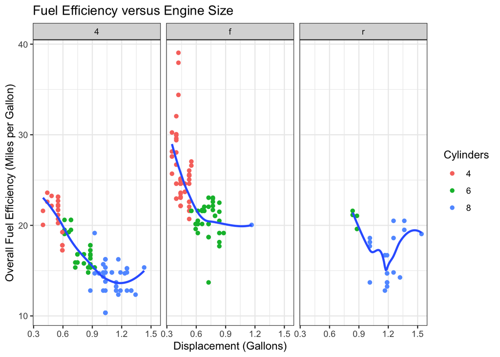

```r
mpg |>
  filter(cyl != 5) |>
  mutate(
    fuel_efficiency = 0.45 * hwy + 0.55 * cty,
    displ_gallons = 0.2199693 * displ
  ) |>
  ggplot(aes(x = displ_gallons, y = fuel_efficiency)) +
    geom_point(aes(colour = factor(cyl))) +
    geom_smooth(se = FALSE) +
    facet_wrap(vars(drv)) +
    theme_bw() +
    labs(
      x = "Displacement (Gallons)",
      y = "Overall Fuel Efficiency (Miles per Gallon)",
      colour = "Cylinders",
      title = "Fuel Efficiency versus Engine Size"
    )
```

- Do you think the “smooth” lines will continue into the future?
  - If we add a front wheel drive (`drv == "f"`) car with an engine displacement of 1.5 gallons, will the smooth line look the same?
  - For 4 wheel drive cars, will larger engine displacements continue to have higher and higher mpg?
  - If we had more rear wheel drive cars, will that wonky smooth pattern still be there?

**Try**: In the plot, there’s one car in with `drv == "f"` and `cyl ==6` that seems to have a much lower `mpg` than the rest. What’s that about? Fill in the code to see if you can gain any information.

```r
mpg |>
  filter() |> # add filters
  mutate(fuel_efficiency = 0.45 * hwy + 0.55 * cty) |>
  arrange() # arrange appropriately
```

```
# A tibble: 234 × 12
   manufacturer model      displ  year   cyl trans drv     cty   hwy fl    class
   <chr>        <chr>      <dbl> <int> <int> <chr> <chr> <int> <int> <chr> <chr>
 1 audi         a4           1.8  1999     4 auto… f        18    29 p     comp…
 2 audi         a4           1.8  1999     4 manu… f        21    29 p     comp…
 3 audi         a4           2    2008     4 manu… f        20    31 p     comp…
 4 audi         a4           2    2008     4 auto… f        21    30 p     comp…
 5 audi         a4           2.8  1999     6 auto… f        16    26 p     comp…
 6 audi         a4           2.8  1999     6 manu… f        18    26 p     comp…
 7 audi         a4           3.1  2008     6 auto… f        18    27 p     comp…
 8 audi         a4 quattro   1.8  1999     4 manu… 4        18    26 p     comp…
 9 audi         a4 quattro   1.8  1999     4 auto… 4        16    25 p     comp…
10 audi         a4 quattro   2    2008     4 manu… 4        20    28 p     comp…
# ℹ 224 more rows
# ℹ 1 more variable: fuel_efficiency <dbl>
```